# plasma: Partial LeAst Squares for Multi-omics Analysis

Kevin R. Coombes

# Introduction

Recent years have seen the development of numerous algorithms and computational packages for the analysis of multi-omics data sets. At this point, one can find multiple review articles summarizing progress in the field (Adossa, Khan, Rytkonen, and Elo 2021; Graw et al. 2021; Heo, Hwa, Lee, Park, and An 2021; Picard, Scott-Boyer, Bodein, Perin, and Droit 2021; Reel, Reel, Pearson, Trucco, and Jefferson 2021; Subramanian, Verma, Kumar, Jere, and Anamika 2020; Vlachavas, Bohn, Uckert, and Nurnberg 2021). As with other applications of machine learning, the kinds of problems addressed by these algorithms are divided into two categories: unsupervised (e.g., clustering or class discovery) or supervised (including class comparison and class prediction) (Simon and Dobbin 2003). Advances in the area of unsupervised learning have been broader and deeper than advances on supervised learning.

One of the most effective unsupervised methods is Multi-Omic Factor Analysis (MOFA) (Argelaguet et al. 2018, 2020). A key property of MOFA is that it does not require all omics assays to have been performed on all samples under study. In particular, it can effectively discover class structure across omics data sets even when data for many patients have only been acquired on a subset of the omics technologies. As of this writing, we do not know of any supervised multi-omics method that can effectively learn to predict outcomes when samples have only been assayed on a subset of the omics data sets.

MOFA starts with a standard method – Latent Factor Analysis – that is known to work well on a single omics data set. It then fits a coherent model that identifies latent factors that are common to, and able to explain the data well in, all the omics data sets under study. Our investigation (unpublished) of the factors found by MOFA suggests that, at least in come cases, it is approximately equivalent to a two-step process:

1. Use principal components analysis to identify initial latent factors in each individual omics data set.
2. For each pair of omics data sets, use overlapping samples to train and extend models of each factor to the union of assayed samples.

# Methods

Our computational method is implemented and the data are available in the `plasma` package.

```r
suppressWarnings( library(plasma) )
packageVersion("plasma")
```

```
## [1] '0.7.16'
```

## Data

```r
loadLUSCdata()
sapply(assemble, dim)
```

```
##      ClinicalBin ClinicalCont MAF Meth450 miRSeq mRNASeq RPPA
## [1,]          61            2 897    1940    872    2290  223
## [2,]         504          504 484     364    338     493  322
```

## Imputation

We recommend imputing small amounts of missing data in the input data sets. The underlying issue is that the PLS models we use for individual omics data sets will not be able to make predictions on a sample if even one data point is missing. As a result, if a sample is missing at least one data point in every omics data set, then it will be impossible to use that sample at all.

For a range of available methods and R packages, consult the [CRAN Task View on Missing Data](https://CRAN.R-project.org/view=MissingData). We also recommend the [R-miss-tastic web site on missing data](https://rmisstastic.netlify.app/). Their simulations suggest that, for purposes of producing predictive models from omics data, the imputation method is not particularly important. Because of the latter finding, we have only implemented two simple imputation methods in the `plasma` package:

1. `meanModeImputer` will replace any missing data by the mean value of the observed data if there are more than five distinct values; otherwise, it will replace missing data by the mode. This approach works relatively well for both continuous data and for binary or small categorical data.
2. `samplingImputer` replaces missing values by sampling randomly from the observed data distribution.

```r
set.seed(54321)
imputed <- lapply(assemble, samplingImputer)
```

## Computational Approach

The `plasma` algorithm is based on Partial Least Squares (PLS), which has been shown to be an effective method for finding components that can predict clinically interesting outcomes (Bastien, Bertrand, Meyer, and Maumy-Bertrand 2015). The workflow of the plasma algorithm is illustrated in **Figure 1** in the case of three omics data sets. First, for each of the omics data sets, we apply the PLS Cox regression algorithm (`plsRcox` Version 1.7.6 (Bertrand and Maumy-Bertrand 2021)) to the time-to-event outcome data to learn three separate predictive models (indicated in red, green, and blue, respectively). Each of these models may be incomplete, since they are not defined for patients who have not been assayed (shown in white) using that particular omics technology. Second, for each pair of omics data sets, we apply the PLS linear regression algorithm (`pls` Version 2.8.0 (Mishra and Liland 2022)) to learn how to predict the coefficients of the Cox regression components from one data set using features from the other data set. This step extends (shown in pastel red, green, and blue, resp.) each of the original models, in different ways, from the intersection of samples assayed on both data sets to their union. Third, we average all of the different extended models (ignoring missing data) to get a single coherent model of component coefficients across all omics data sets. Assuming that this process has been applied to learn the model from a training data set, we can evaluate the final Cox regression model on both the training set and a test set of patient samples.

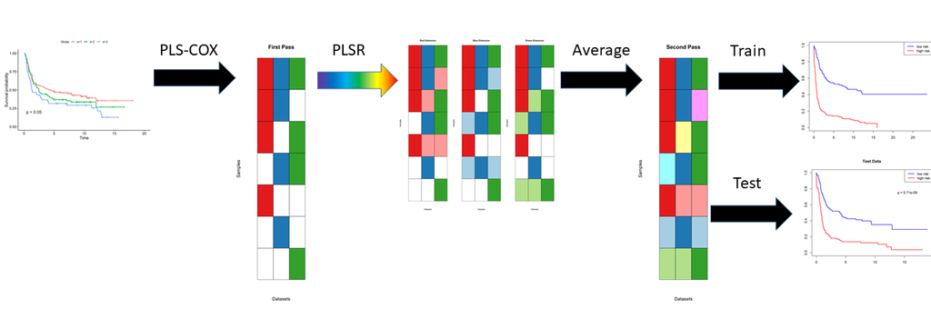

Figure 1 : Workflow schematic for plasma algorithm with three omics data sets. See main text for an explanation.

All computations were performed in R version 4.2.1 (2022-06-23 ucrt) of the R Statistical Software Environment (R Core Team 2022). Cox proportioanl hazards models for survival analysis were fit using version 3.3.1 of e `survival` R package. We used additional exploratory graphical tools from version 1.3.1 of the `beanplot` R package (Kampstra 2008) and version 1.5.1 of the `Polychrome` R package (Coombes, Brock, Abrams, and Abruzzo 2019).

## Terminology

Because of the layered nature of the plasma algorithm, we intend to use the following terminology to help clarify the later discussions.

1. The input data contains a list of *omics data sets*.
2. Each omics data set contains measurements of multiple *features*.
3. The first step in the algorithm uses PLS Cox regression to find a set of *components*. Each component is a linear combination of features. The components are used as predictors in a Cox proportional hazards model, which predicts the log hazard ratio as a linear combination of components.
4. The second step in the algorithm creates a secondary layer of components. We do not give these components a separate name. They are not an item of particular focus; we view them as a way to extend the first level components to more samples by “re-interpreting” them in other omics data sets.

## Preparing the Data

To be consistent with the `MOFA2` R package (Argelaguet et al. 2020), all of the data sets are arranged so that patient samples are columns and assay features are rows. Our first task is to pad each data set with appropriate `NA`’s to ensure that each set includes the same patient samples in the same order, where that order matches the outcome data frame.

```r
MO <- prepareMultiOmics(imputed, Outcome)
summary(MO)
```

```
## Datasets:
##      ClinicalBin ClinicalCont MAF Meth450 miRSeq mRNASeq RPPA
## [1,]          61            2 897    1940    872    2290  223
## [2,]         498          498 498     498    498     498  498
## Outcomes:
```

```
##    patient_id  vital_status days_to_death    days_to_last_followup      Days
##  1000   :  1   alive:283    Min.   :   1.0   Min.   :   0          Min.   :   0.0
##  1002   :  1   dead :215    1st Qu.: 280.0   1st Qu.: 394          1st Qu.: 325.2
##  1005   :  1                Median : 550.0   Median : 757          Median : 666.5
##  1011   :  1                Mean   : 872.3   Mean   :1049          Mean   : 972.6
##  1012   :  1                3rd Qu.:1110.5   3rd Qu.:1374          3rd Qu.:1259.8
##  1016   :  1                Max.   :5287.0   Max.   :4765          Max.   :5287.0
##  (Other):492                NA's   :283      NA's   :215
```

We see that the number of patients in each data set is now equal to the number of patients with clinical outcome data.

## Split Into Training and Test

As indicated above, we want to separate the data set into training and test samples. We will use 60% for training and 40% for testing.

```r
set.seed(54321)
splitVec <- rbinom(nrow(Outcome), 1, 0.6)
```

**Figure 2** presents a graphical overview of the number of samples (`N`) and the number of features (`D`) in each omics component of the training and test sets.

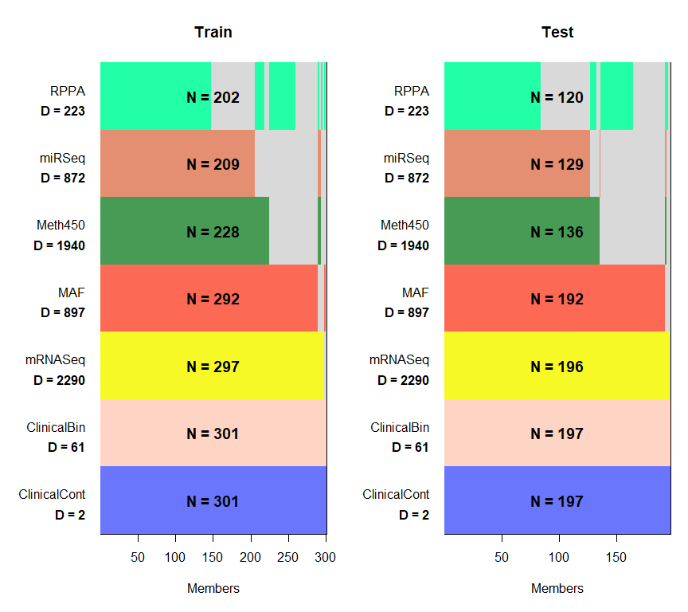

Figure 2 : Overview of training and test data.

```r
trainD <- MO[, splitVec == 1]
testD <- MO[, splitVec == 0]
opar <- par(mai = c(1.02, 1.32, 0.82, 0.22), mfrow = c(1,2))
plot(trainD, main = "Train")
plot(testD, main = "Test")
```

```r
par(opar)
```

# Results

## Individual PLS Cox Regression Models

The first step of the `plasma` algorithm is to fit PLS Cox models on each omics data set using the function `fitCoxModels`. The returned object of class `MultiplePLSCoxModels` contains a list of `SingleModel` objects, one for each assay, and within each there are three regression models:

- The `plsRcoxmodel` contains the coefficients of the components learned by PLS Cox regression. The number of components is determined automatically as a function of the logarithm of the number of features in the omics data set. The output of this model is a continuous prediction of “risk” for the time-to-event outcome of interest.
- Two separate models are constructed using the prediction of risk on the training data.
  - The `riskModel` is a `coxph` model using continuous predicted risk as a single predictor.
  - The `splitModel` is a `coxph` model using a binary split of the risk (at the median) as the predictor.

```r
cache <- "firstPass.Rda"
if (file.exists(cache)) {
  load(cache)
} else {
  suppressWarnings( firstPass <- fitCoxModels(trainD, timevar = "Days",
                            eventvar = "vital_status", eventvalue = "dead") )
  save(firstPass, file = cache)
}
rm(cache)
```

```r
summary(firstPass)
```

```
## An object containing MultiplePLSCoxModels based on:
## [1] "ClinicalBin"  "ClinicalCont" "MAF"          "Meth450"      "miRSeq"       "mRNASeq"
## [7] "RPPA"
```

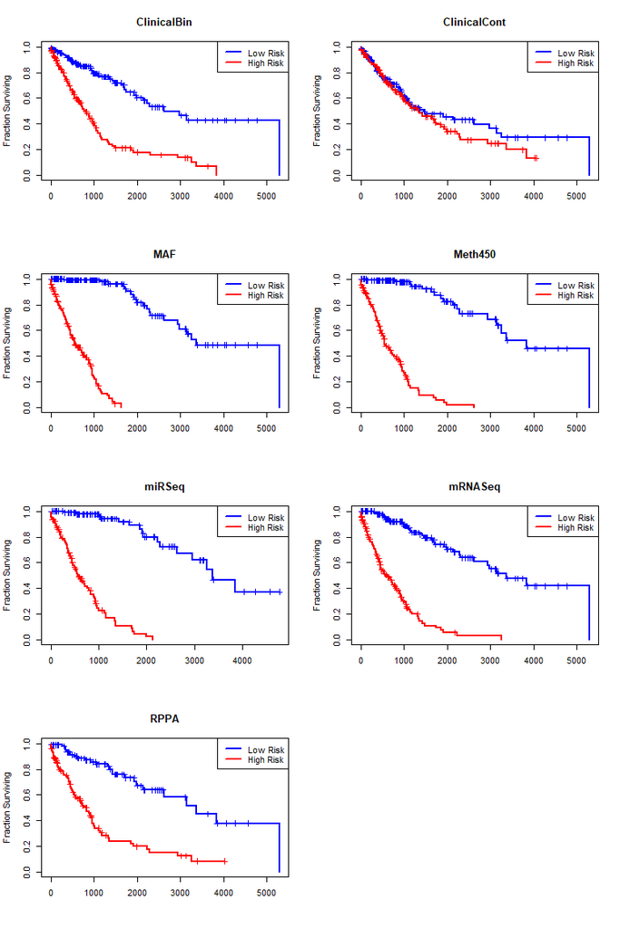

Figure 3 : Kaplan-Meier plots of overall survival on the training set from separate PLS Cox omics models

```r
if (!interactive()) {
  plot(firstPass, legloc = "topright") # margins too small inside RStudio window
}
```

## Extend Model Components Across Omics Data Sets

The second step of the algorithm is to extend the individual omics-based models across other omics data sets. This step is performed using the `plasma` function, which takes in the previously created objects of class `multiOmics` and `MultiplePLSCoxModels`. The function operates iteratively, so in our case there are seven different sets of predictions of the PLS components. These different predictions are averaged and saved internally as a data frame called `meanPredictions`. The structure of models created and stored in the `plasma` object is the same as for the separate, individual, omics models. **Figure 4** shows the Kaplan-Meier plot using the predicted risk, split at the median value, on the training data set.

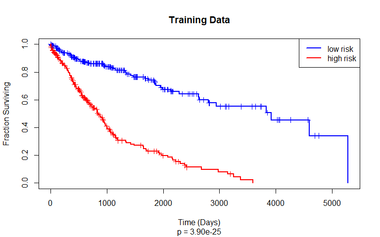

Figure 4 : Kaplan-Meier plot of overall survival on the training set using the unified `plasma` Cox model.

```r
cache = "pl.Rda"
if (file.exists(cache)) {
  load(cache)
} else {
  pl <- plasma(MO, firstPass)
  save(pl, file = cache)
}
rm(cache)
plot(pl, legloc = "topright", main = "Training Data", xlab = "Time (Days)")
```

## Independent Test Set

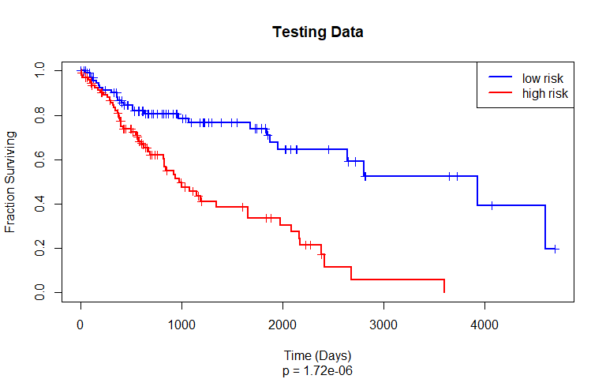

Figure 5 : Kaplan-Meier plot of overall survival on the test set.

```r
testpred <- predict(pl, testD)
plot(testpred, main="Testing Data", xlab = "Time (Days)")
```

## Interpretation

At this point, our model appears to be a fairly complex black box. We have constructed a matrix of components, based on linear combinations of actual features in different omics data sets. These components can then be combined in yet another linear model that predicts the time-to-event outcome through Cox regression. In this section, we want to explore how the individual features from different omics data sets contribute to different model components.

Our first act toward opening the black box is to realize that not all of the components discovered from the individual omics data sets survived into the final composite model. Some components were eliminated because they appeared to be nearly linearly related to components found in other omics data sets. So, we can examine the final composite model more closely.

```r
pl@fullModel
```

```
## Call:
## coxph(formula = Surv(Days, vital_status == "dead") ~ ClinicalBin2 +
##     ClinicalBin3 + MAF1 + MAF2 + MAF3 + MAF4 + Meth4501 + Meth4502 +
##     Meth4503 + Meth4504 + miRSeq1 + miRSeq4 + mRNASeq1 + RPPA2,
##     data = riskDF)
##
##                   coef exp(coef)  se(coef)      z        p
## ClinicalBin2  1.943430  6.982659  0.853921  2.276 0.022853
## ClinicalBin3  1.646241  5.187445  0.622666  2.644 0.008197
## MAF1          0.993317  2.700175  0.146533  6.779 1.21e-11
## MAF2          0.462372  1.587836  0.253874  1.821 0.068566
## MAF3          1.362046  3.904174  0.480869  2.832 0.004619
## MAF4         -5.082248  0.006206  1.536750 -3.307 0.000943
## Meth4501      0.126886  1.135287  0.053448  2.374 0.017597
## Meth4502      0.415770  1.515537  0.129797  3.203 0.001359
## Meth4503      1.381189  3.979632  0.314414  4.393 1.12e-05
## Meth4504      0.840972  2.318620  0.209150  4.021 5.80e-05
## miRSeq1       1.816057  6.147571  0.574857  3.159 0.001582
## miRSeq4       0.609111  1.838796  0.366624  1.661 0.096632
## mRNASeq1     -0.093122  0.911083  0.046610 -1.998 0.045729
## RPPA2         0.307385  1.359864  0.165605  1.856 0.063434
##
## Likelihood ratio test=174.4  on 14 df, p=< 2.2e-16
## n= 498, number of events= 215
```

```r
temp <- terms(pl@fullModel)
mainterms <- attr(temp, "term.labels")
rm(temp)
mainterms
```

```
##  [1] "ClinicalBin2" "ClinicalBin3" "MAF1"         "MAF2"         "MAF3"         "MAF4"
##  [7] "Meth4501"     "Meth4502"     "Meth4503"     "Meth4504"     "miRSeq1"      "miRSeq4"
## [13] "mRNASeq1"     "RPPA2"
```

Our interest now turns to understanding how the features from individual omics data sets contribute to the components that are used in the final model. As mentioned earlier, these contributions are mediated through two levels of linear regression models when extending a model from data set A to data set B. A linear combination of features from set B is used to define the secondary level of components; then a linear combination of these components is used to predict the components of the single Cox model built that had been from set A. These weights can be combined and extracted using the `getAllWeights` function, and can then be explored.

### Clinical Binary Data

We use the binary clinical data set to begin illustrating one method for interpreting the components.

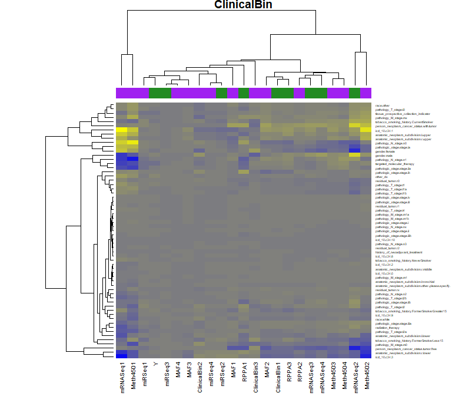

Figure 6 : Unscaled heatmap of the contributions of binary clinical features to all components (purple = retained in final model, green = not retained).

```r
library(oompaBase)
HG <-  blueyellow(64)
cbin <- getAllWeights(pl, "ClinicalBin")
compcolors <- c("forestgreen", "purple")[1 + 1*(colnames(cbin@contrib) %in% mainterms)]
heat(cbin, cexCol = 0.9, cexRow = 0.5, col = HG, ColSideColors = compcolors)
```

**Figure 6** shows the raw weights for each clinical binary feature in all of the original omics components. We would like to simplify this plot in several ways. First, we can remove any components that were not retained in the final model (indicated by the green color bar in the top dendrogram). Second, we hypothesize that some components intrinsically have a wider spread of weights, and that it might be more important to scale the components consistently to look at the relative contributions. Finally, we can remove any features that seem to make no contributions to any of the components; that is; those that do not have highly ranked weights (by absolute value) in any component.

```r
shrink <- function(dset, N) {
  dset@contrib <- scale(dset@contrib)               # standardize
  feat <- unique(unlist(as.list(getTop(dset, N))))  # remove useless features
  dset@contrib <- dset@contrib[feat, mainterms]     # remove unused components
  dset
}
```

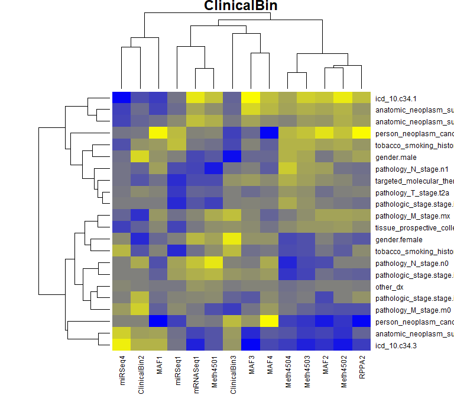

Figure 7 : Scaled heatmap of the contributions of filtered binary clinical features to important components.

```r
xbin <- shrink(cbin, 4)
heat(xbin, cexCol = 0.9, cexRow = 0.9, col = HG)
```

### mRNA-Sequencing Data

We can apply the same method to visualize contributors from each of the omics data sets. As a second illustration, we look at the standardized weights from the mRNA data set in the components that are part of the final model, keeping only those features that are highly ranked by absolute weight in at least one component (**Figure 8**).

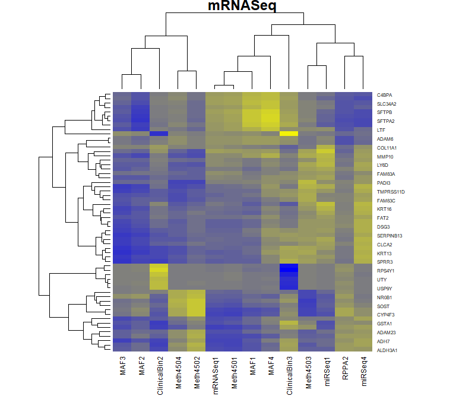

Figure 8 : Scaled heatmap of the contributions of filtered mRNA features to important components

```r
mrna <- getAllWeights(pl, "mRNASeq")
xmrna <- shrink(mrna, 7)
tmp <- rownames(xmrna@contrib)
rownames(xmrna@contrib) <- sapply(strsplit(tmp, "\\."), function(x) x[1])
heat(xmrna, cexCol = 0.9, cexRow = 0.6, col = HG)
```

## Uniting the Contributors

One difficulty with the heatmaps in the previous section is that they are focused on individual input data sets, and not on individual components. In order to fully understand which features contribute, for example, to the first mutation component (MAF1), one would have to scan all the heatmaps from all the datasets and then try to combine the influences. In order to help with that procedure, we can merge all the contributions into a single data frame, with an accompanying factor tracking the source data set.

```r
CW <- combineAllWeights(pl)
contra <- CW@combined
datasrc <- CW@dataSource
```

**Figure 9** displays the mean, standard deviation (SD), median, and median absolute deviation (MAD) of the weight-contributions for each data set in each component.

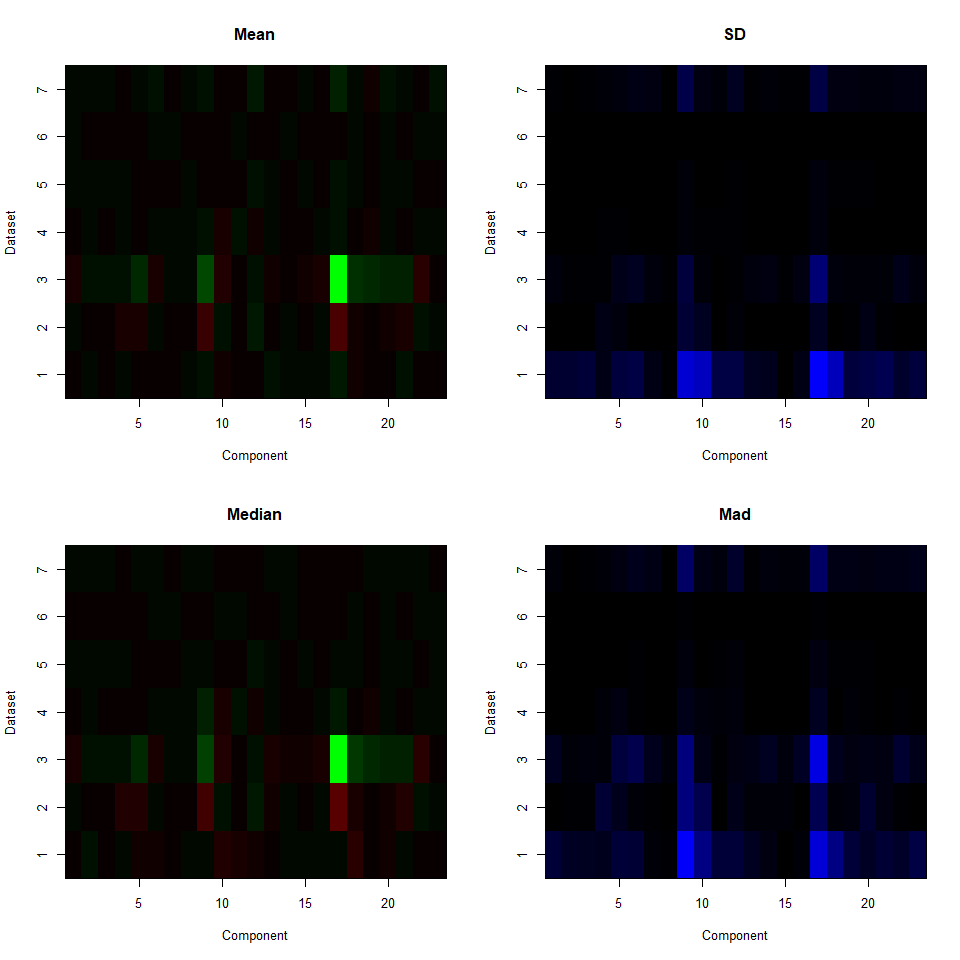

Figure 9 : Summary statistics of weights by component and dataset.

```r
image(CW)
```

## Standardized Weights

To remain consistent with the previous heatmaps, we have standardized the weights in each data set and component. In **Figure 10**, we create beanplots showing the distributions of weights arising from each data set in each (retained) component. (Similar plots for the raw weights are available in **Supplementary Data**.) Some data sets have very different contribution patterns than others. For example, the miRSeq data set appears to have significant outliers making large contributions in almost every component, the MAF and RPPA data sets also frequently (but not always) include such outliers.

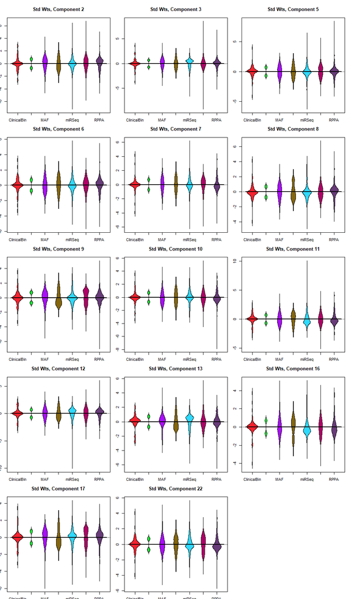

Figure 10 : Distributions of standardized weights by data set and component.

```r
library(beanplot)
library(Polychrome)
data(palette36)
foo <- computeDistances(palette36[3:36])
colist <- as.list(palette36[names(foo)[1:7]])
brute <- stdize(CW, "standard")
opar <- par(mfrow = c(5,3), mai = c(0.2,0.2, 0.5, 0.2))
for (i in which(colnames(contra) %in% mainterms)) {
  beanplot(brute[, i] ~ datasrc, what = c(1,1,1,0), col = colist,
           main = paste("Std Wts, Component", i))
}
par(opar)
```

```r
rm(opar)
```

We also include plots of the histograms of distributions by component (**Figure 11**). None of these really looks quite normal; almost all have some slightly odd shape.

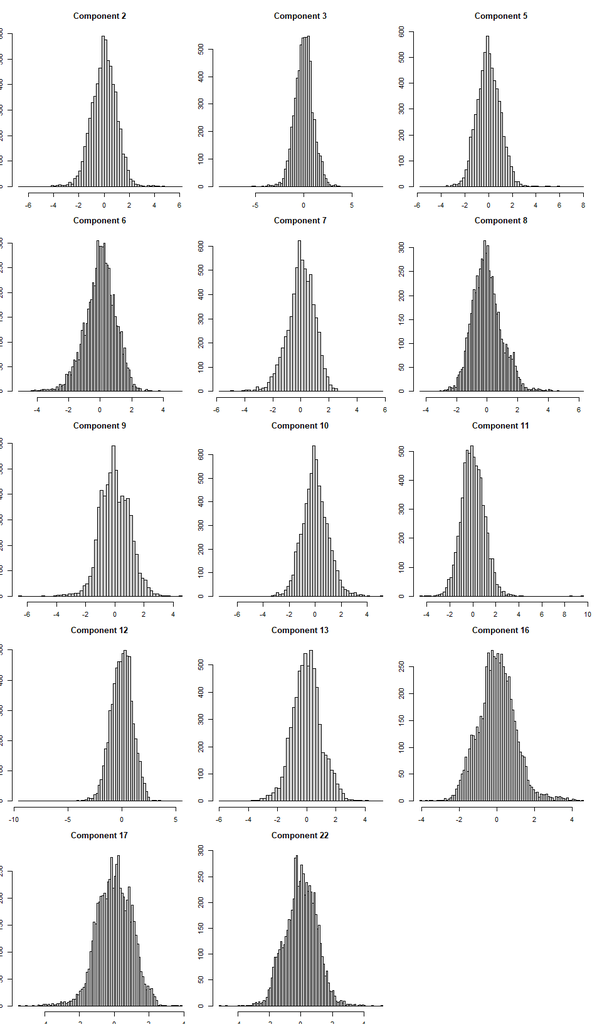

Figure 11 : Histogram of standardized weights by component.

```r
opar <- par(mfrow = c(5, 3), mai = c(0.2,0.2, 0.5, 0.2))
for (i in which(colnames(contra) %in% mainterms)) {
  hist(brute[,i], breaks = 77, main = paste("Component", i))
}
par(opar)
```

```r
rm(opar)
```

## Data Set Sources of Top Twenty Lists

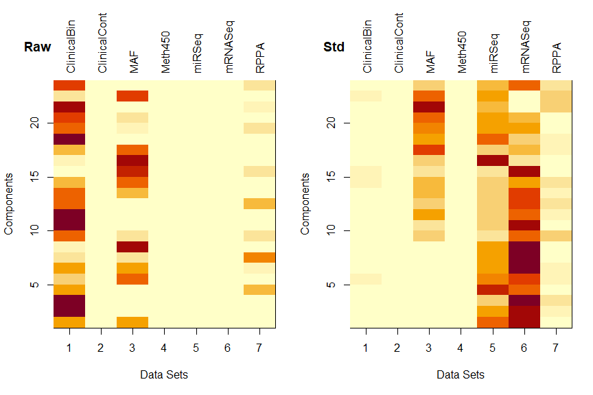

Figure 12 : Number of contributers to top twenty lists.

```r
top20 <- apply(contra, 2, function(X) {
  A <- abs(X)
  S <- rev(sort(A))
  which(A > S[21])
})
top20types <- apply(top20, 2, function(X) {
  table(datasrc[X])
})

chop20 <- apply(brute, 2, function(X) {
  A <- abs(X)
  S <- rev(sort(A))
  which(A > S[21])
})
chop20types <- apply(chop20, 2, function(X) {
  table(datasrc[X])
})

opar <- par(mfrow = c(1, 2), mai = c(1.02, 0.82, 1.22, 0.32))
image(1:7, 1:24, top20types, ylab = "Components", xlab = "Data Sets")
mtext(levels(datasrc), side = 3, at = 1:7, line = 1/2, las=2)
mtext("Raw", side = 3, at = 0, line = 2, font = 2, cex = 1.2)
image(1:7, 1:24, chop20types, ylab = "Components", xlab = "Data Sets")
mtext(levels(datasrc), side = 3, at = 1:7, line = 1/2, las=2)
mtext("Std", side = 3, at = 0, line = 2, font = 2, cex = 1.2)
```

```r
par(opar)
rm(opar)
```

## Overall Distribution of Weights

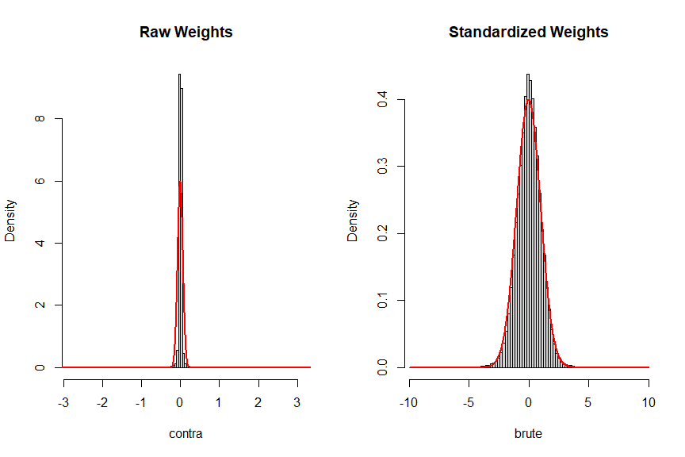

Figure 13 : Histograms of all weights (combined).

```r
opar <- par(mfrow = c(1, 2))
hist(contra, breaks = 123, main = "Raw Weights", prob = TRUE)
xx <- seq(-10, 10, length=1001)
yy <- dnorm(xx, mean(contra), sd(contra))
lines(xx, yy, col = "red", lwd=2)
hist(brute, breaks = 123, main = "Standardized Weights", prob = TRUE)
yy <- dnorm(xx)
lines(xx, yy, col = "red", lwd=2)
```

```r
par(opar)
rm(opar)
```

## Number of Contributers Selected by Normal Significance

Finally, we create yet another image (**Figure 14**), counting the number of significant features from each data set for each component, when using a significance cutoff of 5% derived from the standard normal distribution. We feel that this result is more reasonable than any thing we got just by looking at the top 20 lists. Most contributions come from the biggest omics data sets (mRNA, methylation, and miR) with fewer from MAF, RPPA, and clinical binary.

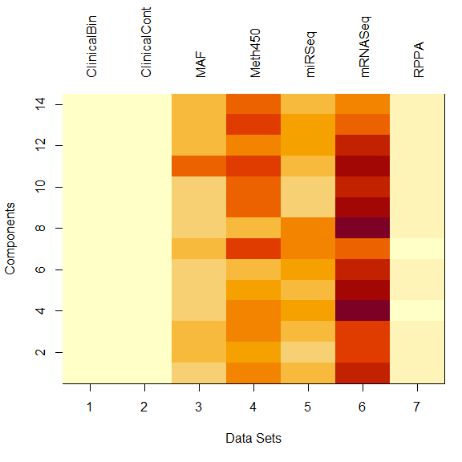

Figure 14 : Number of significant contributions by data set and component.

```r
Q <- qnorm(0.975) # two-sided 5% cutoff
top1p <- aggregate(brute, list(datasrc), function(X) sum(abs(X) > Q)) # top 5 percent
rownames(top1p) <- top1p[, 1]
top1p <- as.matrix(top1p[, -1])
top1p <- top1p[, mainterms]
L <- length(mainterms)
opar <- par(mai = c(1.02, 0.82,1.22, 0.22))
image(1:7, 1:L, top1p, ylab = "Components", xlab = "Data Sets")
mtext(levels(datasrc), side = 3, at = 1:7, line = 1, las=2)
```

```r
par(opar)
```

Here is an overview of all the contributing features.

```r
library(tidyr)
illumina <- read.csv(file.path("https://webdata.illumina.com/downloads/productfiles",
                               "humanmethylation450/humanmethylation450_15017482_v1-2.csv"),
                     skip=7)
illumina <- illumina[, c("IlmnID", "UCSC_RefGene_Name")] # only care about two columns

pickers <- function(dsname, Q = 0.05) {
  pickA <- interpret(CW, dsname, Q)
  rap <- pickA$Feature[pickA$Source == "RPPA"]
  rap <- sapply(strsplit(rap, "\\."), function(x) x[1])
  map <- pickA$Feature[pickA$Source == "MAF"]
  nap <- pickA$Feature[pickA$Source == "mRNASeq"]
  nap <- sapply(strsplit(nap, "\\."), function(x) x[1])
  nap <- nap[-1]
  nick <- rep("", nrow(pickA))
  nick[pickA$Source == "RPPA"] <- rap
  nick[pickA$Source == "MAF"] <- map
  nick[pickA$Source == "mRNASeq"] <- c("", nap)
  pickA$Nickname <- nick

  illuminaFeatures <- illumina[which(illumina$IlmnID %in% pickA$Feature),] # which did we use?
  temp <- strsplit(illuminaFeatures$UCSC_RefGene_Name, ";") # look at duplicates
  temp <- sapply(sapply(temp, unique), paste, collapse=";") # many dups have the same gene name
  illuminaFeatures$UCSC_RefGene_Name <- temp
  expanded <- as.data.frame(separate_rows(illuminaFeatures, UCSC_RefGene_Name, sep=";"))
  M <- merge(pickA, expanded, by.x = "Feature", by.y = "IlmnID", all.x = TRUE, sort = FALSE)
  M$Nickname[M$Nickname == ""] <- M$UCSC_RefGene_Name[M$Nickname == ""]
  M$Nickname[is.na(M$Nickname)] <- ""
  M$UCSC_RefGene_Name <- NULL
  M <- M[order(M$Source, M$Feature), ]

  M
}
pickA <- pickers("ClinicalBin2")
summary(pickA)
```

```
##    Feature                   Source       Weight          Nickname
##  Length:272         ClinicalBin : 5   Min.   :-6.6680   Length:272
##  Class :character   ClinicalCont: 0   1st Qu.:-2.4140   Class :character
##  Mode  :character   MAF         :41   Median :-2.0211   Mode  :character
##                     Meth450     :72   Mean   :-0.3208
##                     miRSeq      :45   3rd Qu.: 2.2699
##                     mRNASeq     :96   Max.   : 6.1734
##                     RPPA        :13
```

We start by looking more closely at the clinical features.

```r
pickA[1:5, ]
```

```
##                      Feature      Source    Weight Nickname
## 73             gender.female ClinicalBin -2.757341
## 74               gender.male ClinicalBin  2.872117
## 75 pathologic_stage.stage.ib ClinicalBin  1.965747
## 76      pathology_M_stage.m0 ClinicalBin  2.696807
## 77      pathology_M_stage.mx ClinicalBin -2.510628
```

```r
pickA[pickA$Source == "MAF", ]
```

```
##      Feature Source    Weight Nickname
## 78  ADAMTS16    MAF -2.241170 ADAMTS16
## 79    AKAP13    MAF  2.155648   AKAP13
## 80     CDH18    MAF -2.472199    CDH18
## 81   CNTNAP5    MAF -2.378060  CNTNAP5
## 82   COL11A1    MAF -2.171134  COL11A1
## 83    COL6A3    MAF -1.978799   COL6A3
## 84     CSMD2    MAF -2.750257    CSMD2
## 85     CSMD3    MAF -3.300840    CSMD3
## 86      CUBN    MAF -2.622299     CUBN
## 87     DCHS2    MAF -3.417828    DCHS2
## 88      DGKI    MAF -2.533558     DGKI
## 89    DNAH10    MAF -2.791308   DNAH10
## 90   FAM135B    MAF -2.231716  FAM135B
## 91      FAT2    MAF  2.022856     FAT2
```

[output cut: 27 more lines]

**CFAP54 (Cilia And Flagella Associated Protein 54)**

Predicted to be involved in cilium assembly; cilium movement involved in cell motility; and spermatogenesis. Predicted to act upstream of or within cerebrospinal fluid circulation; motile cilium assembly; and mucociliary clearance. Predicted to be located in axoneme.

**DNAH9 (Dynein Axonemal Heavy Chain 9)**

This gene encodes the heavy chain subunit of axonemal dynein, a large multi-subunit molecular motor. Axonemal dynein attaches to microtubules and hydrolyzes ATP to mediate the movement of cilia and flagella.

**DYNC2H! (Dynein Cytoplasmic 2 Heavy Chain 1)**

This gene encodes a large cytoplasmic dynein protein that is involved in retrograde transport in the cilium and has a role in intraflagellar transport, a process required for ciliary/flagellar assembly. Mutations in this gene cause a heterogeneous spectrum of conditions related to altered primary cilium function and often involve polydactyly, abnormal skeletogenesis, and polycystic kidneys.

**FBN3 (Fibrillin 3)**

This gene encodes a member of the fibrillin protein family. Fibrillins are extracellular matrix molecules that assemble into microfibrils in many connective tissues. This gene is most highly expressed in fetal tissues and its protein product is localized to extracellular microfibrils of developing skeletal elements, skin, lung, kidney, and skeletal muscle. This gene is potentially involved in Weill-Marchesani syndrome.

**MYH13 (Myosin Heavy Chain 13)**

Predicted to enable microfilament motor activity. Predicted to be involved in muscle contraction. Predicted to act upstream of or within cellular response to starvation. Located in extracellular exosome.

**PCDHA12 (Protocadherin Alpha 12)**

This gene is a member of the protocadherin alpha gene cluster, one of three related gene clusters tandemly linked on chromosome five that demonstrate an unusual genomic organization similar to that of B-cell and T-cell receptor gene clusters. The alpha gene cluster is composed of 15 cadherin superfamily genes related to the mouse CNR genes and consists of 13 highly similar and 2 more distantly related coding sequences. The tandem array of 15 N-terminal exons, or variable exons, are followed by downstream C-terminal exons, or constant exons, which are shared by all genes in the cluster. The large, uninterrupted N-terminal exons each encode six cadherin ectodomains while the C-terminal exons encode the cytoplasmic domain. These neural cadherin-like cell adhesion proteins are integral plasma membrane proteins that most likely play a critical role in the establishment and function of specific cell-cell connections in the brain.

These descriptions clearly indicate some common functional relationships between the mutated genes, including a role in cilia, flagella, and microfibrils.

We then extracted all gene names from the MAF, mRNASeq, and RPPA data sets and used thm to perform a gene enrichment (pathway) analysis using ToppGene (Chen, Bardes, Aronow, and Jegga 2009). Associated GeneOntology Biological Process categories included keratinization, epidermal and epithelial cell development, cell adhesion, intermediate filament organization, and wound healing. GeneOntology Cellular Components included cell-cell junctions, extracellular matrix, and intermediate filaments. Associated human phenotypes included hyperkeratosis (particularly follicular hyperkeratosis), epidermal thickening, and oral leukoplakia. Associated pathways included keratinization, gap junction assembly and trafficking, and both ErbB and mTOR signaling. Associated cytogenetic regions included 1q21-1q22, 18q12.1, and 12q12.13. Associated gene families included cadherins, kallikreins, keratins, and gap-junction proteins. Associated diseases included hyperkertosis, squamous cell carcinoma of the head and neck, intraepithelial neoplasia, endometrial carcinoma, basal-like breast carcinoma, and esophageal carcinoma.

We save all the significant features as separate worksheets in an Excel workbook.

```r
allPicks <- lapply(mainterms, pickers, Q = 0.05)
names(allPicks) <- mainterms
sapply(allPicks, dim)
```

```
##      ClinicalBin2 ClinicalBin3 MAF1 MAF2 MAF3 MAF4 Meth4501 Meth4502 Meth4503 Meth4504 miRSeq1
## [1,]          272          258  269  294  282  268      305      300      290      278     356
## [2,]            4            4    4    4    4    4        4        4        4        4       4
##      miRSeq4 mRNASeq1 RPPA2
## [1,]     291      302   264
## [2,]       4        4     4
```

Now we call a perl script (`toppgene.pl`) to automate the process of retrieving the results of each of the enrichment analyses. Each result is again written to a separate file, in tab-separated-values (TSV) format.

```r
gldir <- "GeneLists"
if (!file.exists(gldir)) dir.create(gldir)

for (I in 1:length(allPicks)) {
  N <- names(allPicks)[I]
  genes <- allPicks[[I]]$Nickname
  genes <- sort(unique(genes[genes != ""]))
  write.table(genes, file = file.path(gldir, paste(N, "txt", sep = ".")),
              sep = "\t", quote = FALSE, row.names = FALSE, col.names = FALSE)
}

outdir <- "TGOUT"
if (!file.exists(outdir)) dir.create(outdir)

fnames <- file.path(gldir, dir(gldir, pattern = "*.txt"))
for (I in 1:length(fnames)) {
  R <- sub("^GeneLists", "TGOUT", sub("txt$", "tsv", fnames[I]))
  if(file.exists(R)) next
  topp <- file.path(getwd(), "toppgene.pl")
  cmd <- paste("C:/Strawberry/perl/bin/perl.exe", topp, file.path(getwd(), fnames[I]))
  sysout <- system(cmd)
  if (sysout) {
    stop("Received error code ", sysout, "\n")
  }
  Sys.sleep(10)
}
```

```r
for (I in 1:length(allPicks)) {
  A <- allPicks[[I]]
  cat ("\n\n-----------------------", names(allPicks)[I], "---------------------n\n")
  print(A[A$Source == "ClinicalBin",])
}
```

```
##
##
## ----------------------- ClinicalBin2 ---------------------n
##                      Feature      Source    Weight Nickname
## 73             gender.female ClinicalBin -2.757341
## 74               gender.male ClinicalBin  2.872117
## 75 pathologic_stage.stage.ib ClinicalBin  1.965747
## 76      pathology_M_stage.m0 ClinicalBin  2.696807
## 77      pathology_M_stage.mx ClinicalBin -2.510628
##
##
## ----------------------- ClinicalBin3 ---------------------n
##                                     Feature      Source    Weight Nickname
## 65                            gender.female ClinicalBin  3.605113
## 66                              gender.male ClinicalBin -3.659229
## 69                     pathology_M_stage.m0 ClinicalBin -2.085204
## 70                     pathology_M_stage.mx ClinicalBin  2.084057
## 67 person_neoplasm_cancer_status.tumor.free ClinicalBin  2.047454
## 68 person_neoplasm_cancer_status.with.tumor ClinicalBin -1.967266
##
##
## ----------------------- MAF1 ---------------------n
##                                     Feature      Source    Weight Nickname
## 71                             icd_10.c34.1 ClinicalBin -2.192357
## 72 person_neoplasm_cancer_status.tumor.free ClinicalBin -4.136764
## 73 person_neoplasm_cancer_status.with.tumor ClinicalBin  3.952391
##
##
## ----------------------- MAF2 ---------------------n
##                                     Feature      Source    Weight Nickname
## 70                             icd_10.c34.1 ClinicalBin  2.389521
## 71                             icd_10.c34.3 ClinicalBin -2.593035
## 72 person_neoplasm_cancer_status.tumor.free ClinicalBin -3.304999
## 73 person_neoplasm_cancer_status.with.tumor ClinicalBin  3.279088
##
##
## ----------------------- MAF3 ---------------------n
##                                  Feature      Source    Weight Nickname
## 67 anatomic_neoplasm_subdivision.r.lower ClinicalBin -2.740606
## 68 anatomic_neoplasm_subdivision.r.upper ClinicalBin  2.946882
```

[output cut: 64 more lines]

```
##
## ----------------------- mRNASeq1 ---------------------n
##                                  Feature      Source    Weight Nickname
## 93 anatomic_neoplasm_subdivision.l.upper ClinicalBin  2.085670
## 94                          icd_10.c34.1 ClinicalBin  3.439292
## 95                          icd_10.c34.3 ClinicalBin -3.065338
## 96                  pathology_N_stage.n0 ClinicalBin  2.253071
##
##
## ----------------------- RPPA2 ---------------------n
##                                     Feature      Source    Weight Nickname
## 91                             icd_10.c34.1 ClinicalBin  2.189440
## 92                             icd_10.c34.3 ClinicalBin -2.204487
## 93 person_neoplasm_cancer_status.tumor.free ClinicalBin -3.941570
## 94 person_neoplasm_cancer_status.with.tumor ClinicalBin  4.030777
```

```r
L <- sapply(allPicks, nrow)
folderol <- do.call(rbind, allPicks)
folderol$Comps <- factor(rep(names(allPicks), L))
summary(folderol)
```

```
##    Feature                   Source         Weight           Nickname              Comps
##  Length:4029        ClinicalBin :  63   Min.   :-9.46156   Length:4029        miRSeq1 : 356
##  Class :character   ClinicalCont:   0   1st Qu.:-2.31651   Class :character   Meth4501: 305
##  Mode  :character   MAF         : 615   Median : 1.96229   Mode  :character   mRNASeq1: 302
##                     Meth450     :1034   Mean   :-0.01043                      Meth4502: 300
##                     miRSeq      : 745   3rd Qu.: 2.28654                      MAF2    : 294
##                     mRNASeq     :1399   Max.   : 9.46925                      miRSeq4 : 291
##                     RPPA        : 173                                         (Other) :2181
```

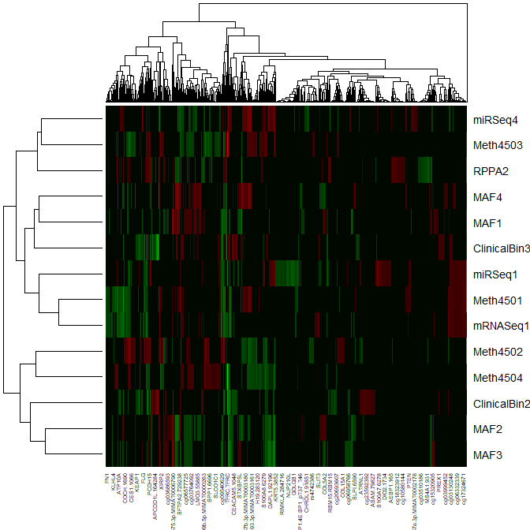

```r
tap <- tapply(folderol$Weight, list(folderol$Feature, folderol$Comps), mean)
tap [is.na(tap)] <- 0
heatmap(t(tap), scale = "none", col = redgreen(64))
```

```r
fl <- dir("TGOUT/", pattern = "tsv$")

blark <- lapply(1:length(fl), function(J) {
  cat(fl[J], "\n")
  sheet <- read.table(file.path("TGOUT", fl[J]),
                      header = TRUE, sep = "\t", fill = TRUE, quote = "")
  sheet <- sheet[sheet$Category %in% c("Cytoband", "Disease", "GO: Biological Process",
                                       "GO: Cellular Component", "Human Phenotype", "Pathway") ,]
  sheet$Category <- factor(sheet$Category)
  sheet$Component <- sub(".txt", "", fl[J])
  sheet
})
```

```
## ClinicalBin2.tsv
## ClinicalBin3.tsv
## MAF1.tsv
## MAF2.tsv
## MAF3.tsv
## MAF4.tsv
## Meth4501.tsv
## Meth4502.tsv
## Meth4503.tsv
## Meth4504.tsv
## miRSeq1.tsv
## miRSeq4.tsv
## mRNASeq1.tsv
## RPPA2.tsv
```

```r
snark <- do.call(rbind, blark)
dim(snark)
```

```
## [1] 1081   15
```

```r
summary(snark)
```

```
##      Category        ID                Name               PValue           QValueFDRBY
##  Cytoband: 58   Length:1081        Length:1081        Min.   :0.000e+00   Min.   :0.0000000
##  Disease :560   Class :character   Class :character   1st Qu.:1.000e-08   1st Qu.:0.0000338
##  Pathway :463   Mode  :character   Mode  :character   Median :6.270e-07   Median :0.0011590
##                                                       Mean   :1.433e-04   Mean   :0.0405920
##                                                       3rd Qu.:5.504e-05   3rd Qu.:0.0309300
##                                                       Max.   :4.927e-03   Max.   :0.3897442
##   QValueFDRBH        QValueBonferroni      TotalGenes     GenesInTerm      GenesInQuery
##  Min.   :0.000e+00   Min.   :0.0000000   Min.   :13609   Min.   :   1.0   Min.   :105.0
##  1st Qu.:3.850e-06   1st Qu.:0.0000512   1st Qu.:13609   1st Qu.:  38.0   1st Qu.:143.0
##  Median :1.317e-04   Median :0.0025993   Median :19383   Median : 128.0   Median :159.0
##  Mean   :5.510e-03   Mean   :0.1148109   Mean   :17643   Mean   : 360.2   Mean   :159.8
##  3rd Qu.:3.992e-03   3rd Qu.:0.0689315   3rd Qu.:19383   3rd Qu.: 630.0   3rd Qu.:173.0
##  Max.   :4.946e-02   Max.   :1.0000000   Max.   :33040   Max.   :1973.0   Max.   :235.0
##  GenesInTermInQuery    Source              URL               Genes            Component
##  Min.   : 1.00      Length:1081        Length:1081        Length:1081        Length:1081
##  1st Qu.: 5.00      Class :character   Class :character   Class :character   Class :character
##  Median :10.00      Mode  :character   Mode  :character   Mode  :character   Mode  :character
##  Mean   :13.83
##  3rd Qu.:22.00
##  Max.   :58.00
```

```r
tap <- tapply(snark$PValue, list(snark$ID, snark$Component), mean)
tap <- -log10(tap)
tap[is.na(tap)] <- 0
dim(tap)
```

```
## [1] 402  14
```

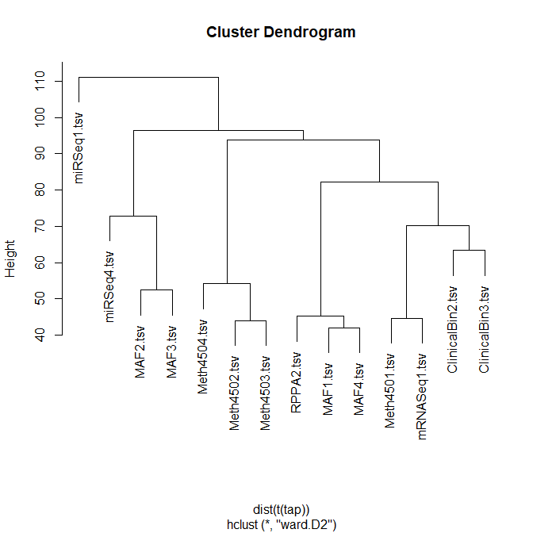

```r
hc <- hclust(dist(t(tap)), "ward.D2")
plot(hc)
```

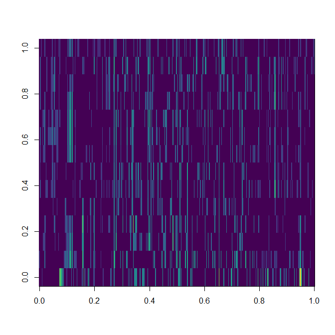

```r
image(tap[, hc$order], col = viridisLite::viridis(64))
```

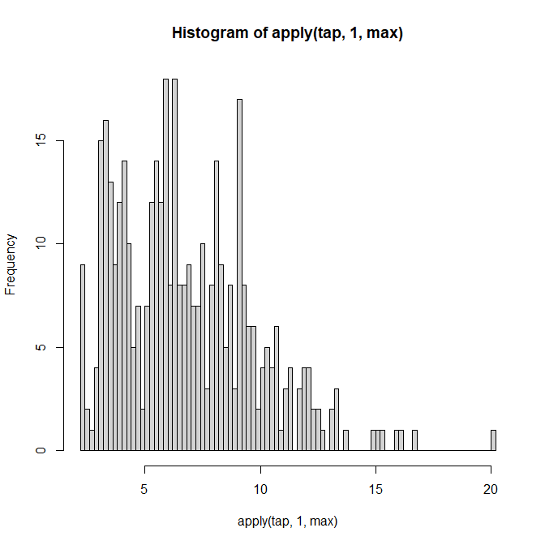

```r
hist(apply(tap, 1, max), breaks = 123)
```

# Conclusions

We have identified a method analogous to that of `MOFA` that allows us to combine different omics data without the need for prior imputation of missing values. A major difference is that while `MOFA` model learns “factors” that are composites of the variables in an unsupervised fashion, the `plasma` model learns “components” that are composites of the variables in an supervised fashion, using the outcomes “event” and “time-to-event” as response variables.

# References

Adossa N, Khan S, Rytkonen KT, Elo LL (2021). “Computational Strategies for Single-Cell Multi-Omics Integration.” *Comput Struct Biotechnol J*, **19**, 2588–2596. Journal Article. [https://doi.org/10.1016/j.csbj.2021.04.060.](https://doi.org/10.1016/j.csbj.2021.04.060)

Argelaguet R, Arnol D, Bredikhin D, Deloro Y, Velten B, Marioni JC, Stegle O (2020). “MOFA+: A Statistical Framework for Comprehensive Integration of Multi-Modal Single-Cell Data.” *Genome Biol*, **21**(1), 111. Journal Article. [https://doi.org/10.1186/s13059-020-02015-1.](https://doi.org/10.1186/s13059-020-02015-1)

Argelaguet R, Velten B, Arnol D, Dietrich S, Zenz T, Marioni JC, Buettner F, Huber W, Stegle O (2018). “Multi-Omics Factor Analysis-a Framework for Unsupervised Integration of Multi-Omics Data Sets.” *Mol Syst Biol*, **14**(6), e8124. Journal Article. [https://doi.org/10.15252/msb.20178124.](https://doi.org/10.15252/msb.20178124)

Bastien P, Bertrand F, Meyer N, Maumy-Bertrand M (2015). “Deviance Residuals-Based Sparse PLS and Sparse Kernel PLS Regression for Censored Data.” *Bioinformatics*, **31**(3), 397–404. Journal Article. [https://doi.org/10.1093/bioinformatics/btu660.](https://doi.org/10.1093/bioinformatics/btu660)

Bertrand F, Maumy-Bertrand M (2021). “Fitting and Cross-Validating Cox Models to Censored Big Data with Missing Values Using Extensions of Partial Least Squares Regression Models.” *Front Big Data*, **4**, 684794. Journal Article. [https://doi.org/10.3389/fdata.2021.684794.](https://doi.org/10.3389/fdata.2021.684794)

Cancer Genome Atlas Research Network (2017). “Integrated Genomic Characterization of Oesophageal Carcinoma.” *Nature*, **541**(7636), 169–175. Journal Article. [https://doi.org/10.1038/nature20805.](https://doi.org/10.1038/nature20805)

Chen J, Bardes EE, Aronow BJ, Jegga AG (2009). “ToppGene Suite for Gene List Enrichment Analysis and Candidate Gene Prioritization.” *Nucleic Acids Res*, **37**(Web Server issue), W305–11. Journal Article. [https://doi.org/10.1093/nar/gkp427.](https://doi.org/10.1093/nar/gkp427)

Coombes KR, Brock G, Abrams ZB, Abruzzo LV (2019). “Polychrome: Creating and Assessing Qualitative Palettes with Many Colors.” *Journal of Statistical Software*, **90**(1), 1–23. Journal Article. [https://doi.org/10.18637/jss.v090.c01.](https://doi.org/10.18637/jss.v090.c01)

Graw S, Chappell K, Washam CL, Gies A, Bird J, Robeson 2nd M. S., Byrum SD (2021). “Multi-Omics Data Integration Considerations and Study Design for Biological Systems and Disease.” *Mol Omics*, **17**(2), 170–185. Journal Article. [https://doi.org/10.1039/d0mo00041h.](https://doi.org/10.1039/d0mo00041h)

Heo YJ, Hwa C, Lee GH, Park JM, An JY (2021). “Integrative Multi-Omics Approaches in Cancer Research: From Biological Networks to Clinical Subtypes.” *Mol Cells*, **44**(7), 433–443. Journal Article. [https://doi.org/10.14348/molcells.2021.0042.](https://doi.org/10.14348/molcells.2021.0042)

Jensen MA, Ferretti V, Grossman RL, Staudt LM (2017). “The NCI Genomic Data Commons as an Engine for Precision Medicine.” *Blood*, **130**(4), 453–459. Journal Article. [https://doi.org/10.1182/blood-2017-03-735654.](https://doi.org/10.1182/blood-2017-03-735654)

Kampstra P (2008). “Beanplot: A Boxplot Alternative for Visual Comparison of Distributions.” *Journal of Statistical Software*, **28**(1), 1–9. Journal Article. Retrieved from https://doi.org/10.18637/jss.v028.c01

Mishra P, Liland KH (2022). “Swiss Knife Partial Least Squares (SKPLS): One Tool for Modelling Single Block, Multiblock, Multiway, Multiway Multiblock Including Multi-Responses and Meta Information Under the ROSA Framework.” *Anal Chim Acta*, **1206**, 339786. Journal Article. [https://doi.org/10.1016/j.aca.2022.339786.](https://doi.org/10.1016/j.aca.2022.339786)

Picard M, Scott-Boyer MP, Bodein A, Perin O, Droit A (2021). “Integration Strategies of Multi-Omics Data for Machine Learning Analysis.” *Comput Struct Biotechnol J*, **19**, 3735–3746. Journal Article. [https://doi.org/10.1016/j.csbj.2021.06.030.](https://doi.org/10.1016/j.csbj.2021.06.030)

R Core Team (2022). *R: A Language and Environment for Statistical Computing*. Book, R Foundation for Statistical Computing, Vienna, Austria. Retrieved from https://www.R-project.org/

Reel PS, Reel S, Pearson E, Trucco E, Jefferson E (2021). “Using Machine Learning Approaches for Multi-Omics Data Analysis: A Review.” *Biotechnol Adv*, **49**, 107739. Journal Article. [https://doi.org/10.1016/j.biotechadv.2021.107739.](https://doi.org/10.1016/j.biotechadv.2021.107739)

Simon RM, Dobbin K (2003). “Experimental Design of DNA Microarray Experiments.” *Biotechniques*, **Suppl**, 16–21. Journal Article. Retrieved from https://www.ncbi.nlm.nih.gov/pubmed/12664680

Subramanian I, Verma S, Kumar S, Jere A, Anamika K (2020). “Multi-Omics Data Integration, Interpretation, and Its Application.” *Bioinform Biol Insights*, **14**, 1177932219899051. Journal Article. [https://doi.org/10.1177/1177932219899051.](https://doi.org/10.1177/1177932219899051)

Vlachavas EI, Bohn J, Uckert F, Nurnberg S (2021). “A Detailed Catalogue of Multi-Omics Methodologies for Identification of Putative Biomarkers and Causal Molecular Networks in Translational Cancer Research.” *Int J Mol Sci*, **22**(6). Journal Article. [https://doi.org/10.3390/ijms22062822.](https://doi.org/10.3390/ijms22062822)